# Laboratorio_Actividad_1

*Aprendizaje Automático*

*Máster Universitario en Inteligencia Artificial*

*Estudiante: Jonnier Moreno Bertel*

*Fecha: 3/01/2026*

# Laboratorio: Regresión lineal y árboles de decisión para tareas de regresión

## Objetivos

Mediante esta actividad se pretende que ponga en práctica los pasos para la resolución de un problema de machine learning, el tratamiento de datos y la creación de modelos basados en regresión lineal y árboles de decisión. El objetivo es comprender de forma práctica con un problema determinado las diferencias que existen a la hora de entrenar los diferentes modelos.

- Iniciarse en el Análisis Exploratorio de Datos (EDA) para los problemas de Machine Learning.
- Entender y aplicar los conceptos de la Regresión Lineal Múltiple a un problema de regresión.
- Entender y aplicar los conceptos de Árboles de Decisión a un problema de regresión.
- Evaluar y analizar los resultados de los clasificadores.
- Investigar la aplicación de los modelos de clasificación a problemas reales.

## Descripción de la actividad

Debes completar los espacios indicados en el notebook con el código solicitado y la respuesta, en función de lo que se solicite. Ten encuenta que las celdas vacías indican cuántas líneas debe ocupar la respuesta, por lo general no más de una línea.

El conjunto de datos con el que vamos a trabajar se encuentra en el siguiente enlace: https://archive.ics.uci.edu/dataset/360/air+quality

Se trata de un dataset con un conjunto de datos sobre calidad del aire. El conjunto de datos contiene 9358 instancias de respuestas promediadas por hora de una matriz de 5 sensores químicos de óxido de metal integrados en un dispositivo multisensor químico de calidad del aire. El dispositivo estaba ubicado en un área significativamente contaminada, al nivel de la carretera, dentro de una ciudad italiana. Los datos se registraron desde marzo de 2004 hasta febrero de 2005 (un año).

El objetivo de la regresión será predecir la calidad del aire para un determinado día.

### Tareas que se deben realizar

- Análisis descriptivo de los datos:
  - Debe completarse el código solicitado y responder a las preguntas. Todo ello en el notebook dado como base.
- Regresión:
  - Debe completarse el código solicitado y responder a las preguntas. Todo ello en el notebook dado como base.
- Investigación:
  - Buscar un artículo científico (https://scholar.google.es/) con un caso de uso de regresión empleando una de las dos técnicas (o ambas) vistas en la actividad. Los artículos deben estar en revistas científicas, y deben ser posteriores a 2015. No debe utilizar técnicas de Deep Learning.
  - Para el artículo indicar:
    - Objetivo: cuál es el objetivo de la investigación, es decir a qué problema real está aplicando la regresión.
    - Cómo utilizan las técnicas de regresión, si realizan alguna adaptación de los algoritmos indicarse.
    - Principales resultados de la aplicación y de la investigación.

### Análisis descriptivo de los datos

A continuación vas a encontrar una serie de preguntas que tendrás que responder. Para responder tendrás que escribir (y ejecutar) una (o más de una) línea de código, y a continuación indicar la respuesta en la celda indicada.

```python
## cargar el dataset
import pandas as pd
df_air_quality = pd.read_csv("./air+quality/AirQualityUCI.csv", sep=";", decimal=",")
df_air_quality
```

|  | Date | Time | CO(GT) | PT08.S1(CO) | NMHC(GT) | C6H6(GT) | PT08.S2(NMHC) | NOx(GT) | PT08.S3(NOx) | NO2(GT) | PT08.S4(NO2) | PT08.S5(O3) | T | RH | AH | Unnamed: 15 | Unnamed: 16 |
| --- | --- | --- | --- | --- | --- | --- | --- | --- | --- | --- | --- | --- | --- | --- | --- | --- | --- |
| 0 | 10/03/2004 | 18.00.00 | 2.6 | 1360.0 | 150.0 | 11.9 | 1046.0 | 166.0 | 1056.0 | 113.0 | 1692.0 | 1268.0 | 13.6 | 48.9 | 0.7578 | NaN | NaN |
| 1 | 10/03/2004 | 19.00.00 | 2.0 | 1292.0 | 112.0 | 9.4 | 955.0 | 103.0 | 1174.0 | 92.0 | 1559.0 | 972.0 | 13.3 | 47.7 | 0.7255 | NaN | NaN |
| 2 | 10/03/2004 | 20.00.00 | 2.2 | 1402.0 | 88.0 | 9.0 | 939.0 | 131.0 | 1140.0 | 114.0 | 1555.0 | 1074.0 | 11.9 | 54.0 | 0.7502 | NaN | NaN |
| 3 | 10/03/2004 | 21.00.00 | 2.2 | 1376.0 | 80.0 | 9.2 | 948.0 | 172.0 | 1092.0 | 122.0 | 1584.0 | 1203.0 | 11.0 | 60.0 | 0.7867 | NaN | NaN |
| 4 | 10/03/2004 | 22.00.00 | 1.6 | 1272.0 | 51.0 | 6.5 | 836.0 | 131.0 | 1205.0 | 116.0 | 1490.0 | 1110.0 | 11.2 | 59.6 | 0.7888 | NaN | NaN |
| ... | ... | ... | ... | ... | ... | ... | ... | ... | ... | ... | ... | ... | ... | ... | ... | ... | ... |
| 9466 | NaN | NaN | NaN | NaN | NaN | NaN | NaN | NaN | NaN | NaN | NaN | NaN | NaN | NaN | NaN | NaN | NaN |
| 9467 | NaN | NaN | NaN | NaN | NaN | NaN | NaN | NaN | NaN | NaN | NaN | NaN | NaN | NaN | NaN | NaN | NaN |
| 9468 | NaN | NaN | NaN | NaN | NaN | NaN | NaN | NaN | NaN | NaN | NaN | NaN | NaN | NaN | NaN | NaN | NaN |
| 9469 | NaN | NaN | NaN | NaN | NaN | NaN | NaN | NaN | NaN | NaN | NaN | NaN | NaN | NaN | NaN | NaN | NaN |
| 9470 | NaN | NaN | NaN | NaN | NaN | NaN | NaN | NaN | NaN | NaN | NaN | NaN | NaN | NaN | NaN | NaN | NaN |

9471 rows × 17 columns

```python
## ¿cuántas instancias tiene el dataset?
rows_df = len(df_air_quality)
print(f"El número de instancias es: {rows_df}")
```

```
El número de instancias es: 9471
```

¿Cuántas instancias tiene el dataset?

Existe en el dataset un total de 9471 instancias o registros, esto, teniendo en cuenta que inicialmente no se ha realizado el tratamiento del dataset. Este dato contradice la cantidad de instancias que son mencionadas en la descripción de la actividad (se mencionan un total de 9358), sin embargo, se puede estudiar si las dimensiones del dataset una vez realizada durante la exploración de los datos y la limpieza de los mismos coinciden con lo mencionado en la descripción, pues se asume que el valor de 9358 no es mencionado a la ligera.

```python
## ¿cuál es el tipo de datos de cada una de las columnas?
df_air_quality.info()
```

```
<class 'pandas.core.frame.DataFrame'>
RangeIndex: 9471 entries, 0 to 9470
Data columns (total 17 columns):
 #   Column         Non-Null Count  Dtype
---  ------         --------------  -----
 0   Date           9357 non-null   object
 1   Time           9357 non-null   object
 2   CO(GT)         9357 non-null   float64
 3   PT08.S1(CO)    9357 non-null   float64
 4   NMHC(GT)       9357 non-null   float64
 5   C6H6(GT)       9357 non-null   float64
 6   PT08.S2(NMHC)  9357 non-null   float64
 7   NOx(GT)        9357 non-null   float64
 8   PT08.S3(NOx)   9357 non-null   float64
 9   NO2(GT)        9357 non-null   float64
 10  PT08.S4(NO2)   9357 non-null   float64
 11  PT08.S5(O3)    9357 non-null   float64
 12  T              9357 non-null   float64
 13  RH             9357 non-null   float64
 14  AH             9357 non-null   float64
 15  Unnamed: 15    0 non-null      float64
 16  Unnamed: 16    0 non-null      float64
dtypes: float64(15), object(2)
memory usage: 1.2+ MB
```

¿Cuál es el tipo de datos de cada una de las columnas?

Dentro del dataset existe un total de 2 atributos de tipo "object" tales como: Date, Time.

Adicionalmente en este mismo dataset, existe un total de 15 atributos de tipo "float64" tales como: PT08.S1(CO), NMHC(GT), PT08.S2(NMHC), NOx(GT), PT08.S3(NOx), NO2(GT) PT08.S4(NO2), PT08.S5(O3), CO(GT), C6H6 (GT), T, RH y AH, Unnamed: 15 y Unnamed: 16.

Se destaca (como se suponía) que la cantidad de instancias dentro del dataset mencionadas en la descripción obedecen a una razón, esta razón es la cantidad de elementos no nulos de cada uno de los atributos, extendidos desde el primer elemento cuyo id es 0 hasta el ultimo elemento cuyo id es 9357.

```python
## ¿cuántas columnas categóricas hay? ¿y cuántas continuas?
def count_categotical_or_continuous(df_air_quality : pd, type_element : str):
    number_categorical_element = (df_air_quality.dtypes == type_element).sum()
    return int(number_categorical_element)

number_categorical_atribute = count_categotical_or_continuous(df_air_quality, "object")
print(f"La cantidad de atributos categóricos son: {number_categorical_atribute}")

number_continuos_element = count_categotical_or_continuous(df_air_quality, "float64")
print(f"La cantidad de atributos continuos son: {number_continuos_element}")
```

```
La cantidad de atributos categóricos son: 2
La cantidad de atributos continuos son: 15
```

¿cuántas columnas categóricas hay? ¿y cuántas continuas?

Existen un total de 2 atributos o columnas categóricas, aunque normalmente, la columna cuyo nombre es Date hace referencia a fechas no es especificamente una categoria como tal sino un tipo de variables dentro de las bases de datos de tipo Date. Si se quiere ser muy especifico, esta columna (Date) no contaria como un atributo categórico, reduciendose así el número de atributos categóricos a 1.

```python
## ¿existen valores nulos en el dataset?
df_null_number = df_air_quality.isnull().sum()
print(f"Total de elementos nulos en el dataset: {int(df_null_number.sum())}")
print("Distribución de nulos por atributos dentro del dataset:")
df_null_number
```

```
Total de elementos nulos en el dataset: 20652
Distribución de nulos por atributos dentro del dataset:
```

```
Date              114
Time              114
CO(GT)            114
PT08.S1(CO)       114
NMHC(GT)          114
C6H6(GT)          114
PT08.S2(NMHC)     114
NOx(GT)           114
PT08.S3(NOx)      114
NO2(GT)           114
PT08.S4(NO2)      114
PT08.S5(O3)       114
T                 114
RH                114
AH                114
Unnamed: 15      9471
Unnamed: 16      9471
dtype: int64
```

¿Existen valores nulos en el dataset?

En efecto. Realizando el analisis exploratorio de los datos, se halló que existen multiples datos nulos dentro del dataset.

En el dataset se puede encontrar dos columnas o atributos cuyos elementos son enteramente nulos y adicionalmente en los demás atributos también existen elementos nulos, realizando un conteo a través de las funciones de la librería Pandas, se puede determinar que la cantidad de estos elementos nulos es de 20652.

```python
## ¿cuál es la variable respuesta? ¿de qué tipo es?

def output_revisor(df_output_revisor: pd, concentration_atribute: str):
    # Valor total de los elementos al interior del dataset
    df_len =  int(len(df_output_revisor))
    # Valor total de los elementos nulos de una columna respuesta indicada al interior de un dataset
    df_null_len = int(df_output_revisor[[concentration_atribute]].isnull().sum().item())

    # Conteo de variables cuyo valor es -200 y que corresponden a variables nulas al interior del dataset según se especifica en la documentación del mismo
    df_minus_200_len =  df_output_revisor[concentration_atribute].value_counts().get(-200)

    # Valor nulo total
    df_total_null = df_null_len + df_minus_200_len

    # # Proporción valores nulos con contenido total del dataset
    df_proportion_null_element = df_total_null/df_len
    print(f"La proporción de elementos nulos para el atributo {concentration_atribute} es de {(df_proportion_null_element * 100):.2f}%")

# Analisis porcentual de elementos nulos en relación a elemtos totales del dataset de atributos respuesta
concentration_atributes = ["CO(GT)", "NMHC(GT)", "C6H6(GT)", "NOx(GT)", "NO2(GT)"]
for concentration_atribute in concentration_atributes:
    output_revisor(df_air_quality, concentration_atribute)
```

```
La proporción de elementos nulos para el atributo CO(GT) es de 18.97%
La proporción de elementos nulos para el atributo NMHC(GT) es de 90.35%
La proporción de elementos nulos para el atributo C6H6(GT) es de 5.07%
La proporción de elementos nulos para el atributo NOx(GT) es de 18.51%
La proporción de elementos nulos para el atributo NO2(GT) es de 18.54%
```

¿Cuál es la variable respuesta? ¿de qué tipo es?

Antes de dar una respuesta a las anteriores preguntas, es necesario realizar un analisis a fondo del dataset obtenido, en el sentido de que existen muchos atributos en el dataset y no es muy sabio tomar de forma aleatorio una variable e indicar que recibe la característica de variable de respuesta. En analisis es dado a continuación:

El estudiante da por sentado (teniendo en cuenta la naturaleza de la actividad y del curso) que se está trabajando bajo el enfoque de aprendizaje supervisado, esto quiere decir (como puede resultar obvio), que dentro del dataset de los datos existirá alguna o algunas variables que harán referencia a la salida del sistema, tal como se ha estudiado a lo largo de la materia.

Estas variables de respuesta, salida o esperadas, no pueden ser las que en descripción reciben el nombre de "respuesta del sensor", pues son la medición a lo largo de las horas de los 5 sensores químicos mencionadas en la descripción del dataset, son en ultimas y especificamente las entradas del sistema, esta variables dentro del dataset reciben el nombre de PT08(S1, S2, S3, S4 y S5), lo cual permite quitarlas como candidatas de ser variable respuesta.

Se ponen bajo estudio los atributos Date y Time, estos atributos, hacen referencia a fechas en las que se tomaron las mediciones y la hora en que se tomó las mediciones respectivamente, por tanto mas que ser salidas, son variables de entradas que indican el momento en que se tomó la medición con los diferentes sensores.

Para los atributos, T (Temperatura), RH (Humedad relativa), AH (Humedad absoluta), es verdaderamente dificil definir para el estudiante si pueden o no pueden ser salidas del sistema pues a partir de los demás datos el enfoque de la actividad podría ser estudiarlos. No obstante, como se está trabajando (como se mencionó anteriormente) bajo el enfoque de aprendizaje supervisado, se debe contar con una variable real y este "real" es lo que decanta al estudiante para seleccionar otras variables como respuesta y tomar T, RH y AH como entradas del sistema que bien podrían hacer parte de un arreglo de sensores adicionales.

En ultimas quedan las variables C6H6, NOx, NO2, CO, NMHC y O3, las cuales son variables de concentración "real" (nombradas así en la pagina de referencia de donde se obtiene el dataset), claro, cabe aclarar que no se tendrá en cuenta O3 cuya variable de respuesta al sensor existe (PT08.S5), pero no existe como tal el atributo O3 dentro del dataset de referencia o simplemente no se encuentra disponible.

En resumen, las variables C6H6, NOx, NO2, CO y NMHC, representan la concentración promedio horaria real dentro del datatset, para el estudiante resultan convincentes como "variables respuestas" tras el analisis previamente realizado. Sin embargo, habría que ser más rigurosos y tener en cuenta cuales de estas son verdaderamente utiles en terminos de contenido en cada uno de sus registros y cuales no. Para ello, se desarrolló un algoritmo que le permite al estudiante conocer el valor porcentual de elementos nulos o considerados faltantes siendo estos ultimos aquellos cuyo valor es -200, en relación con el total de los registros o instancias del dataset.

Se obtiene entonces del script que la variable de entrada NMHC(GT) es completamente inutilizable, su contenido es practicamente está conformado de valores no utiles debido a que la información que aporta es 90.35% nula y sin respuesta. Para las variables CO(GT), NOx(GT) y NO2(GT) pueden ser descartables pues la perdida de información de las mismas ronda aproximadamente el 18.5% de los datos de cada atributo individualmente, facilitandole al benceno o C6H6 ser la candidata ideal para variable respuesta, pues el contenido faltanto y nulo apenas sobrepasa el 5.07%, por tanto, se toma el benceno como variable respuesta y adicionalmente se menciona que es de tipo continuo (float64).

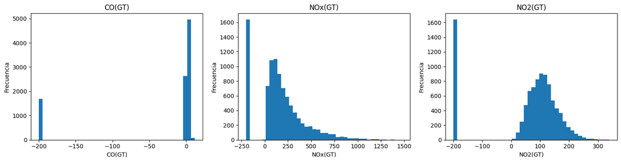

```python
## Si te fijas en los estadísticos del dataset, ¿cómo es la distribución de las variables, CO, NOx y NO2?

import matplotlib.pyplot as plt

columns = ["CO(GT)", "NOx(GT)", "NO2(GT)"]
df_distribution_atributes = df_air_quality[columns]

fig, axis = plt.subplots( 1, len(columns), figsize=(15, 4))

for i, column in enumerate(columns):

    # Se toman series individuales del dataframe para graficar el histograma
    s = df_distribution_atributes[column]

    # Histogramas
    axis[i].hist(s, bins=40)
    axis[i].set_title(column)
    axis[i].set_xlabel(column)
    axis[i].set_ylabel("Frecuencia")

plt.tight_layout()
plt.show()
```

¿Cómo es la distribución de las variables, CO, NOx y NO2?

¿Estas variables muestran alguna distribución especial? ¿Tienen datos faltantes?¿y datos anómalos?

Las distribuciones indican que las características poseen muchos datos faltantes como se puede evidenciar en el histograma, esto en cuanto los valores númericos se refuere, adicionalmente, se tiene constancia de que existen muchos valores nulos los cuales fueron calculados previamente dando un valor de 114 valores nulos en cada una de estas características.

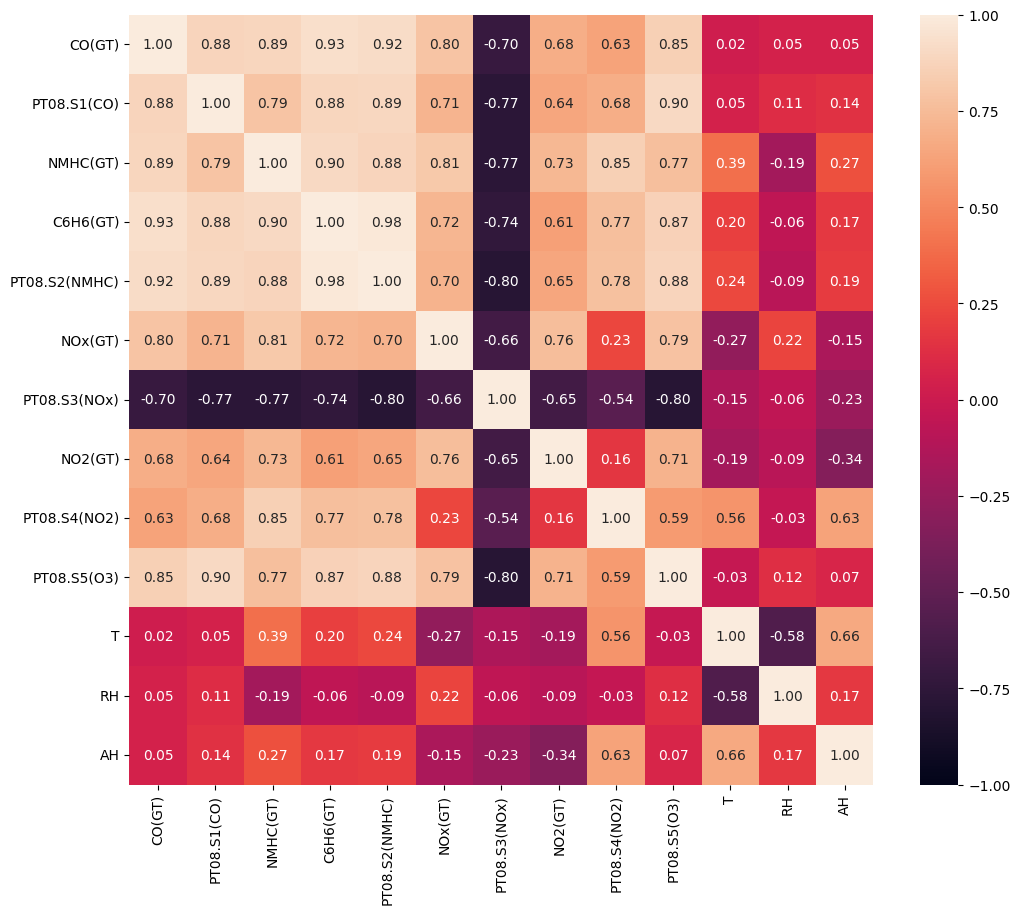

```python
## ¿cómo son las correlaciones entre las variables del dataset?
import seaborn as sns
import numpy as np
colums = ["CO(GT)", "PT08.S1(CO)",	"NMHC(GT)",	"C6H6(GT)",	"PT08.S2(NMHC)", "NOx(GT)", "PT08.S3(NOx)",	"NO2(GT)", "PT08.S4(NO2)", "PT08.S5(O3)", "T", "RH", "AH"]

# Limpieza del dataset
df_air_continuous = df_air_quality[colums].apply(pd.to_numeric,errors="coerce")
df_air_continuous = df_air_continuous.replace(-200, np.nan)

# Calculo de correlación
correlation_matrix = df_air_continuous.corr(method="pearson")

# Mapa de calor de la correlación
plt.figure(figsize=(12, 10))
ax = sns.heatmap(correlation_matrix, annot = True, fmt=".2f", vmin=-1, vmax=1,)
```

¿Cómo son las correlaciones entre las variables del dataset?

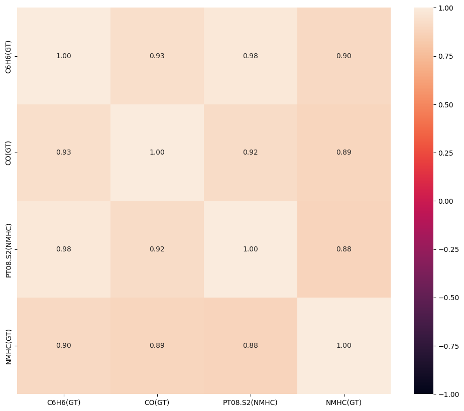

```python
## ¿qué tres variables son las más correlacionadas con la variable objetivo?
sub_colums = ["C6H6(GT)", "CO(GT)",	"PT08.S2(NMHC)", "NMHC(GT)"]

# Limpieza del dataset
sub_df_air_continuous = df_air_quality[sub_colums].apply(pd.to_numeric,errors="coerce")
sub_df_air_continuous = sub_df_air_continuous.replace(-200, np.nan)

# Calculo de correlación
sub_correlation_matrix = sub_df_air_continuous.corr(method="pearson")

# Mapa de calor de la correlación
plt.figure(figsize=(12, 10))
ax = sns.heatmap(sub_correlation_matrix, annot = True, fmt=".2f", vmin=-1, vmax=1,)
```

¿Qué tres variables son las más correlacionadas con la variable objetivo?

Teniendo en cuenta que la variable objetivo seleccionada en items anteriores fue el benceno C6H6 y la matriz de correlación general, las tres variables mas correlacionadas con el mismo son CO(GT) con un 0.93, PT08.S2(NMHC) con un 0.98 y NMHC(GT) con un 0.90, todas con una correlación y fuerza en dirección positiva

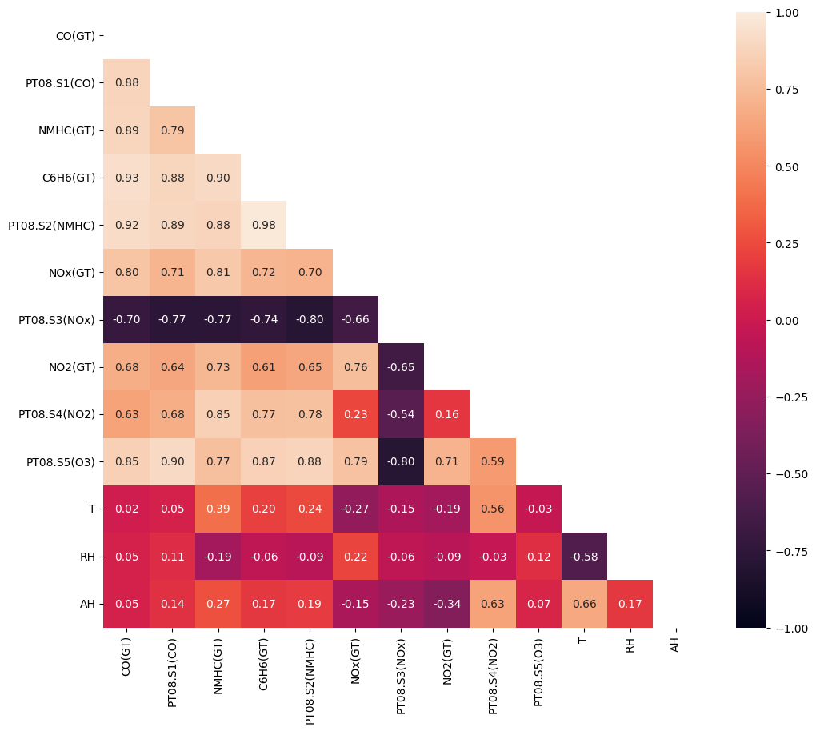

```python
## ¿existe alguna variable que no tenga correlación?

mask = np.triu(np.ones_like(correlation_matrix, dtype=bool))
# Limpieza del dataset
df_air_continuous = df_air_quality[colums].apply(pd.to_numeric,errors="coerce")
df_air_continuous = df_air_continuous.replace(-200, np.nan)

# Calculo de correlación
correlation_matrix = df_air_continuous.corr(method="pearson")

# Mapa de calor de la correlación
plt.figure(figsize=(12, 10))
ax = sns.heatmap(correlation_matrix, mask=mask, annot = True, fmt=".2f", vmin=-1, vmax=1,)
```

¿existe alguna variable que no tenga correlación?

Existen variables con correlaciones muy cercanas a cero, como las ya mencionadas T, RH y AH, con la mayoría de vairables estar presentan correlaciones y fuerzas débiles con la mayoría de las variables.

En base al EDA realizado, ¿qué suposiciones se pueden hacer sobre los datos? ¿qué conclusiones extraes para implementar el modelo predictivo?

El dataset tal cual como está es muy amable para quien de él ve una oportunidad de explorar los datos y utilizarlos en diferentes estudios, sin embargo, existen multiples outliers que pueden y deben ser tratados como previo procedimiento a la implementación de modelos predictivos, así como también aquellos valores y atributos nulos que no aportan ningún tipo de información y podrían hacer que el entrenamiento de los datos ocupe mas recursos y que en últimas cuentas, se llegue como resultado a un modelo de bajo desempeño. Adicionalmente se menciona que la tarea objetivo a lo largo del desarrollo es una tarea de aprendizaje supervisado de regresión, dado a la variable objetivo seleccionada, se busca predecir la concentración de Benceno (C6H6(GT)), la cual es una variable continua, a partir de lecturas de sensores PT, Se utilizará regresión simple, polinómica y arboles de decisión aparte de la evaluación de métricas de interes.

### Regresión

Para llevar a cabo la tarea de regresión deseada se pretender hacer una comparativa de varios modelos. Unos usarán el algortimo de regresión lineal, y otros realizarán la predicción haciendo uso de árboles de decisión.

Para los primeros modelos hay que usar el módulo https://scikit-learn.org/stable/modules/generated/sklearn.linear_model.LinearRegression.html

El algortimo de Regresión Lineal necesita saber cuáles son las variables que va a tener en cuenta para realizar la estimación.

El primero modelo que se debe construir usará una regresión lineal simple. Para ello sigue los siguientes pasos.

Antes de empezar con la implementación de los modelos hace falta realizar una transformación de datos, escalarlos.

```python
from sklearn.preprocessing import MinMaxScaler
from sklearn.preprocessing import StandardScaler
from pandas import DataFrame


scaler = StandardScaler()
```

```python
# Entradas que favorecen a la salida C6H6(GT) según la matriz de correlación
colums = ["CO(GT)", "PT08.S1(CO)", "NMHC(GT)", "PT08.S2(NMHC)", "NOx(GT)", "PT08.S3(NOx)", "NO2(GT)", "PT08.S4(NO2)", "PT08.S5(O3)", "C6H6(GT)"]

# Se analizan las columnas asociadas a los atributos para determinar la proporción de nulo y elementos que no aportan información con el valor -200
for concentration_atribute in colums:
    output_revisor(df_air_quality, concentration_atribute)

# Se descartan aquellos atributos cuyo porcentaje es superior al 10%, se resalta la aparente casualidad de que las variables PT, posean un porcentaje de 5.07% al igual que la salida de interés C6H6
colums_ = ["PT08.S1(CO)", "PT08.S2(NMHC)", "PT08.S3(NOx)", "PT08.S4(NO2)", "PT08.S5(O3)", "C6H6(GT)"]

# Limpieza del dataset, se construye el dataset con las columnas de interés aquellas que no poseen un gran número de elementos nulos y se realiza el tratamiento de los datos
# Este nuevo dataset será el que se considerará original para el resto del proceso
df_air_continuous = df_air_quality[colums_].apply(pd.to_numeric,errors="coerce")
df_air_continuous = df_air_continuous.replace(-200, np.nan)

# Dado que no se tiene certeza de que cada 5.07% de las variables PT de los sensores, coíncida con el 5.07% de la variable objetivo C6H6 se corre el riesgo al hacer dropna de perder muchos datos
# No obstante, el estudiante cree que no es casualidad ese 5.07%
# Para demostrarlo, el número de instancias al aplicar dropna a todos los datos del dataset, debe ser igual al número de instancias originales del dataset actual menos el 5.07% del número de instancias originales del dataset actual
print(f"Elementos totales del dataset: {len(df_air_continuous)}\nValor esperado asociado al 5.07% de los datos que se debe obtener al aplicar dropna: {round(len(df_air_continuous) - len(df_air_continuous)*0.0507)}")
df_air_continuous_modified = df_air_continuous.dropna()
print(f"Numero de elementos despues de eliminar elementos vacios: {len(df_air_continuous_modified)} y Voilà")
```

```
La proporción de elementos nulos para el atributo CO(GT) es de 18.97%
La proporción de elementos nulos para el atributo PT08.S1(CO) es de 5.07%
La proporción de elementos nulos para el atributo NMHC(GT) es de 90.35%
La proporción de elementos nulos para el atributo PT08.S2(NMHC) es de 5.07%
La proporción de elementos nulos para el atributo NOx(GT) es de 18.51%
La proporción de elementos nulos para el atributo PT08.S3(NOx) es de 5.07%
La proporción de elementos nulos para el atributo NO2(GT) es de 18.54%
La proporción de elementos nulos para el atributo PT08.S4(NO2) es de 5.07%
La proporción de elementos nulos para el atributo PT08.S5(O3) es de 5.07%
La proporción de elementos nulos para el atributo C6H6(GT) es de 5.07%
Elementos totales del dataset: 9471
Valor esperado asociado al 5.07% de los datos que se debe obtener al aplicar dropna: 8991
Numero de elementos despues de eliminar elementos vacios: 8991 y Voilà
```

```python
from sklearn.model_selection import train_test_split
# separar datos de entrenamiento y test

# Entradas del sistemas (Todas menos C6H6(GT) que corresponde a la salida)
_input = df_air_continuous_modified[["PT08.S2(NMHC)"]]
# _inputs = df_air_continuous_modified.drop(columns=["C6H6(GT)"])

# Escoger la variable que a partir del EDA realizado, consideres que mejor va a realizar la predicción
# Salida del sistema, ya se ha mencioando que sería el C6H6(GT) o Benceno
output = df_air_continuous_modified["C6H6(GT)"]

# Separación de elemntos en subconjuntos de entrenamiento y prueba
X_train, X_test, y_train, y_test = train_test_split(_input, output, test_size=0.2, shuffle=True, random_state=42)

scaler_x = MinMaxScaler(feature_range=(0, 1))
X_train = DataFrame(scaler_x.fit_transform(X_train), columns=_input.columns, index=X_train.index)
X_test = DataFrame(scaler_x.transform(X_test), columns=_input.columns, index=X_test.index)
```

```
Coeficiente de correlación de Pearson: 0.982
P-value: 0.000
```

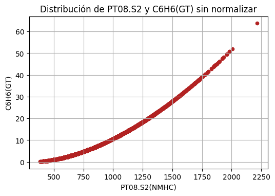

```python
# Coeficiente de pearson
from scipy.stats import pearsonr
# Obtención de coeficiende pearson y p value.
corr_PTS2_C6H6 = pearsonr(x = _input["PT08.S2(NMHC)"], y = output)
# Grafico
fig, ax = plt.subplots(figsize=(6, 3.84))
# Figura sin normalizar
df_air_continuous_modified.plot(x = "PT08.S2(NMHC)", y = "C6H6(GT)", c= "firebrick", kind="scatter", ax=ax, grid=True)
ax.set_title("Distribución de PT08.S2 y C6H6(GT) sin normalizar")
print(f"Coeficiente de correlación de Pearson: {corr_PTS2_C6H6[0]:.3f}")
print(f"P-value: {corr_PTS2_C6H6[1]:.3f}")
```

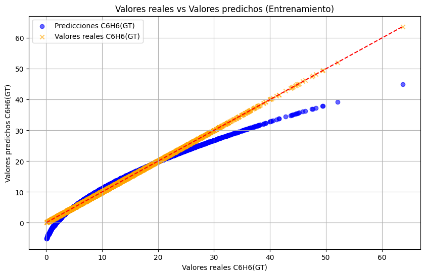

```python
from sklearn.linear_model import LinearRegression
# entrena el modelo con los datos de entrenamiento
model = LinearRegression()
model.fit(X=X_train, y = y_train)

y_train_pred = model.predict(X_train)

#Grafica de datos y_train - y_train_pred
plt.figure(figsize=(10,6))
plt.scatter(y_train, y_train_pred, label='Predicciones C6H6(GT)', marker='o', color='blue', alpha=0.6)
plt.scatter(y_train, y_train, label='Valores reales C6H6(GT)', marker='x', color='orange', alpha=0.6)
plt.xlabel("Valores reales C6H6(GT)")
plt.ylabel("Valores predichos C6H6(GT)")
plt.title("Valores reales vs Valores predichos (Entrenamiento)")
plt.plot([y_train.min(), y_train.max()], [y_train.min(), y_train.max()], color='red', linestyle='--')
plt.grid(True)
plt.legend()
plt.show()
```

```python
# ¿Cuáles son los valores aprendidos por el modelo para los parámetros?

# Información del modelo
# Pendiente para PT08.S2(NMHC) respecto la salida:
slope = model.coef_[0]
# Pendiente
print(f"Pendiente: m(PT08.S2) = {slope:.2f}")
intercept = model.intercept_
# Intercepto
print(f"Intercepto: b = {intercept:.2f}")
#Modelo
print(f"Modelo entrenado: y = {slope:.2f}x + {intercept:.2f}")
# Coeficiente de determinación R^2
print(f"Coeficiente de determinación para entrenamiento: R^2 = {model.score(X_train, y_train):.4}")
```

```
Pendiente: m(PT08.S2) = 50.05
Intercepto: b = -5.12
Modelo entrenado: y = 50.05x + -5.12
Coeficiente de determinación para entrenamiento: R^2 = 0.9639
```

Explica qué indican estos parámetros:

El módelo aprendió diferentes parámetros asociados a la ecuación de la recta, existirán diferentes pendientes asociadas a cada una a las columnas del dataframe de interés, recordando dichas entradas estas son "PT08.S1(CO)", "PT08.S2(NMHC)", "PT08.S3(NOx)", "PT08.S4(NO2)" y "PT08.S5(O3)", sin embargo, se elecciona la columna con mayor correlación con C6H6(GT). Se puede representar la variable de mayor correlación con respecto a la salida "C6H6(GT)" y se obtendría una nube de puntos que a simple vista permitiría deducir si es sustancial o no utilizar regresión lineal para el dataset.

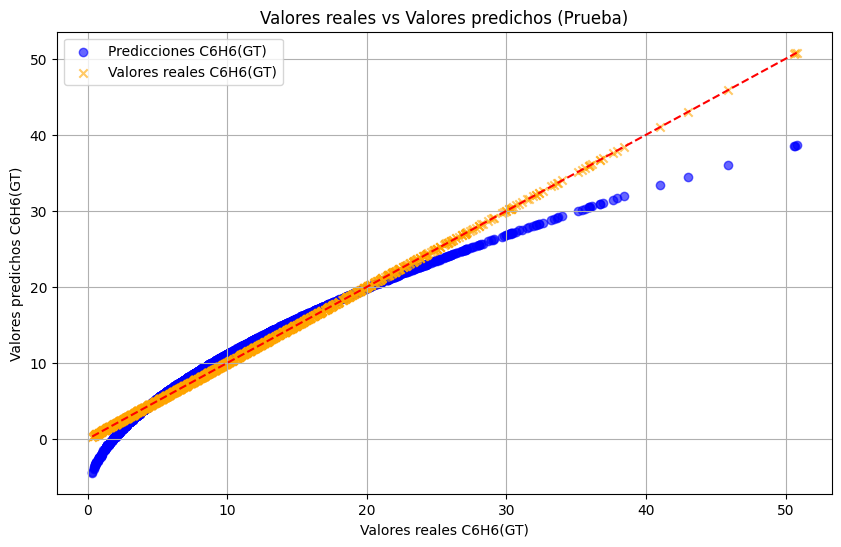

```python
# realiza las predicciones para el conjunto de datos de test

y_test_pred = model.predict(X_test)

# Grafica de datos y_test - y_test_pred
plt.figure(figsize=(10,6))
plt.scatter(y_test, y_test_pred, label='Predicciones C6H6(GT)', marker='o', color='blue', alpha=0.6)
plt.scatter(y_test, y_test, label='Valores reales C6H6(GT)', marker='x', color='orange', alpha=0.6)
plt.xlabel("Valores reales C6H6(GT)")
plt.ylabel("Valores predichos C6H6(GT)")
plt.title("Valores reales vs Valores predichos (Prueba)")
plt.plot([y_test.min(), y_test.max()], [y_test.min(), y_test.max()], color='red', linestyle='--')
plt.legend()
plt.grid(True)
plt.show()
```

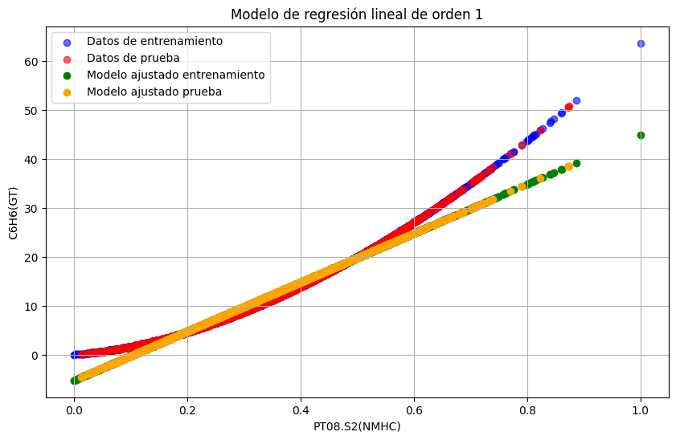

```python
# Visualización de resultados

plt.figure(figsize=(10,6))
plt.scatter(X_train, y_train, color="blue", label = "Datos de entrenamiento", alpha=0.6, marker='o')
plt.scatter(X_test, y_test, color="red", label = "Datos de prueba", alpha=0.6, marker='o')
plt.scatter(X_train, model.predict(X_train) , color="green", label = "Modelo ajustado entrenamiento", marker='o')
plt.scatter(X_test, model.predict(X_test) , color="orange", label = "Modelo ajustado prueba", marker='o')
plt.title("Modelo de regresión lineal de orden 1")
plt.xlabel("PT08.S2(NMHC)")
plt.ylabel("C6H6(GT)")
plt.legend()
plt.grid(True)
plt.show()
```

```python
from sklearn.metrics import mean_squared_error, mean_absolute_error
from math import sqrt
import statsmodels.api as sm

# Ahora es necesario evaluar el modelo. ¿Qué métrica es mejor utilizar en este caso?
y_train_pred = model.predict(X_train)

# Evaluación de modelo con métricas para entrenamiento
mse_train = mean_squared_error(y_train, y_train_pred)
mae_train = mean_absolute_error(y_train, y_train_pred)

print("\nMétricas en el cojunto de entrenamiento")
print(f"MAE: {mae_train}, MSE: {mse_train}")

# Evaluación de modelo con métricas para test
mse_test = mean_squared_error(y_test, y_test_pred)
mae_test = mean_absolute_error(y_test, y_test_pred)
print("\nMétricas en el cojunto de pruebas")
print(f"MAE: {mse_test}, MSE: {mae_test}")
```

```
Métricas en el cojunto de entrenamiento
MAE: 1.0168222841796384, MSE: 1.9817169377608754

Métricas en el cojunto de pruebas
MAE: 2.001566664455875, MSE: 1.01350453277085
```

¿Qué métrica es mejor utilizar en este caso?

En este caso que se está trabajando con regresiones, las mejores métricas a utilizar son las de error cuadrático medio, error absoluto medio, y la métrica del coeficiente de determinación, las primeras dos por sí solas no indican algo de valor, sin embargo, cuando se entrene un segundo modelo se podrá comparar los valores, la tercera la de coeficiente de determinación indica que tan fiel son los puntos la recta con la distribución real de los datos.

```python
# ¿Qué error tiene el modelo? Explícalo.

# Matriz de predictores:
X_train_predictor = sm.add_constant(X_train, prepend=True)
pedictor_model = sm.OLS(endog=y_train, exog=X_train_predictor)
pedictor_model = pedictor_model.fit()

print(pedictor_model.summary())
```

```
                            OLS Regression Results
==============================================================================
Dep. Variable:               C6H6(GT)   R-squared:                       0.964
Model:                            OLS   Adj. R-squared:                  0.964
Method:                 Least Squares   F-statistic:                 1.922e+05
Date:                Mon, 05 Jan 2026   Prob (F-statistic):               0.00
Time:                        16:19:46   Log-Likelihood:                -12665.
No. Observations:                7192   AIC:                         2.533e+04
Df Residuals:                    7190   BIC:                         2.535e+04
Df Model:                           1
Covariance Type:            nonrobust
=================================================================================
                    coef    std err          t      P>|t|      [0.025      0.975]
---------------------------------------------------------------------------------
const            -5.1158      0.038   -133.720      0.000      -5.191      -5.041
PT08.S2(NMHC)    50.0487      0.114    438.437      0.000      49.825      50.272
==============================================================================
Omnibus:                     4304.880   Durbin-Watson:                   1.986
Prob(Omnibus):                  0.000   Jarque-Bera (JB):            60157.030
Skew:                           2.624   Prob(JB):                         0.00
Kurtosis:                      16.160   Cond. No.                         7.52
==============================================================================

Notes:
[1] Standard Errors assume that the covariance matrix of the errors is correctly specified.
```

Existen diferentes métricas de error en el modelo, sin embargo, se hablará del "std err" obtenido anteriormente, este indica la incertidumbre de los coefiencientes del modelo de regresión respecto al ajuste de los datos, entre más cercano sea este error a cero, se indica que el modelo es más preciso.

Ahora debes entrenar un segundo modelo que haga uso de una regresión lineal múltiple con todas las variables del dataset. Después de entrenar, realiza las predicciones para este segundo modelo.

```python
from sklearn.preprocessing import PolynomialFeatures

# Entradas del sistemas (Todas menos C6H6(GT) que corresponde a la salida)
_inputs = df_air_continuous_modified.drop(columns=["C6H6(GT)"])

# Escoger la variable que a partir del EDA realizado, consideres que mejor va a realizar la predicción
# Salida del sistema, ya se ha mencioando que sería el C6H6(GT) o Benceno
output = df_air_continuous_modified["C6H6(GT)"]


# Separación de elemntos en subconjuntos de entrenamiento y prueba
X_train, X_test, y_train, y_test = train_test_split(_inputs, output, test_size=0.2, shuffle=True, random_state=42)

scaler_x = MinMaxScaler(feature_range=(0, 1))
X_train = DataFrame(scaler_x.fit_transform(X_train), columns=_inputs.columns, index=X_train.index)
X_test = DataFrame(scaler_x.transform(X_test), columns=_inputs.columns, index=X_test.index)

poly = PolynomialFeatures(degree=2, include_bias=False)

# Polinomios
x_train_poly = poly.fit_transform(X_train)
x_test_poly = poly.transform(X_test)

#Modelo
model_poly = LinearRegression()
model_poly.fit(x_train_poly, y_train)

#Predicción de entrenamiento
y_train_pred_poly = model_poly.predict(x_train_poly)


# Predicción de pruebas
y_test_pred_poly = model_poly.predict(x_test_poly)
```

```
Métricas para polinomios de entrenamiento
R2 train: 0.9999299727032993
MAE train: 0.044356447961363406
RMSE train: 0.06203984386424773

Métricas para polinomios de prueba
R2 test : 0.9999337719542745
MAE test: 0.04459424801895249
RMSE test: 0.06168960456731937
```

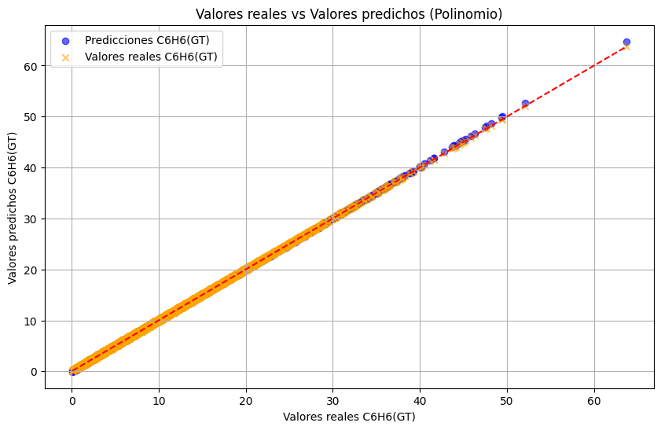

```python
from sklearn.metrics import mean_squared_error, r2_score

print("Métricas para polinomios de entrenamiento")
print("R2 train:", r2_score(y_train, y_train_pred_poly))
print("MAE train:", mean_absolute_error(y_train, y_train_pred_poly))
print("RMSE train:", np.sqrt(mean_squared_error(y_train, y_train_pred_poly)))

print("\nMétricas para polinomios de prueba")
print("R2 test :", r2_score(y_test, y_test_pred_poly))
print("MAE test:", mean_absolute_error(y_test, y_test_pred_poly))
print("RMSE test:", np.sqrt(mean_squared_error(y_test, y_test_pred_poly)))

#Grafica y_train_pred_poly y y_train
plt.figure(figsize=(10,6))
plt.scatter(y_train, y_train_pred_poly, label='Predicciones C6H6(GT)', marker='o', color='blue', alpha=0.6)
plt.scatter(y_train, y_train, label='Valores reales C6H6(GT)', marker='x', color='orange', alpha=0.6)
plt.xlabel("Valores reales C6H6(GT)")
plt.ylabel("Valores predichos C6H6(GT)")
plt.title("Valores reales vs Valores predichos (Polinomio)")
plt.plot([y_train.min(), y_train.max()], [y_train.min(), y_train.max()], color='red', linestyle='--')
plt.grid(True)
plt.legend()
plt.show()
```

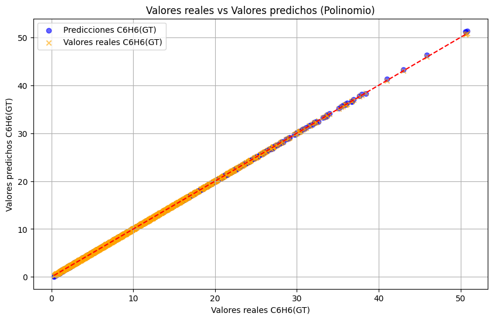

```python
#Grafica de y_test_pred_poly y y_test
plt.figure(figsize=(10,6))
plt.scatter(y_test, y_test_pred_poly, label='Predicciones C6H6(GT)', alpha=0.6, marker='o', color='blue')
plt.scatter(y_test, y_test, label='Valores reales C6H6(GT)', alpha=0.6, marker='x', color='orange')
plt.xlabel("Valores reales C6H6(GT)")
plt.ylabel("Valores predichos C6H6(GT)")
plt.title("Valores reales vs Valores predichos (Polinomio)")
plt.plot([y_test.min(), y_test.max()], [y_test.min(), y_test.max()], color='red', linestyle='--')
plt.legend()
plt.grid(True)
plt.show()
```

¿Qué error tiene este modelo?¿Es mejor o peor que el anterior?